# Statewide Digital Equity Plan: Digital Need and Demographic Analysis

# Set up

```r
source("C:/Users/ziacovino/Desktop/digital-equity/libraries.R")
```

```
sf_use_s2() is TRUE

The following rio suggested packages are not installed: ‘arrow’, ‘hexView’, ‘fst’, ‘pzfx’, ‘rmatio’, ‘readODS’, ‘qs’
Use 'install_formats()' to install them


*** Please call arc.check_product() to define a desktop license.
Registering fonts with R
```

# Digital Need

For digital need:

```
Est. Households without Internet (ACS Table S2801: Computers and Internet Subscriptions; Variable noint:)

Est. Households without Computing Devices (ACS Table S2801: Computers and Internet Subscriptions; Variable nocmp:)

Est. Households with only a Smartphone (ACS Table S2801: Computers and Internet Subscriptions; Variable moblo:)
```

## Pulling Data

```r
#variables
acs_year <- '2018-22' #this will update some but not all of the SQL scripts below


digital_need_query <- paste0("SELECT ct20_id, noint, nointm, noint_p, noint_mp,
                                nocmp, nocmpm, nocmp_p, nocmp_mp,
                                moblo, moblom, moblo_p, moblo_mp
                        FROM tabular.s2801_computer_internet_acs_ct
                        WHERE acs_year = '", acs_year, "'")

digital_need <- fetch(dbSendQuery(ch.ds, digital_need_query), n = -1)
```

## Min Max Digital Need and Scoring

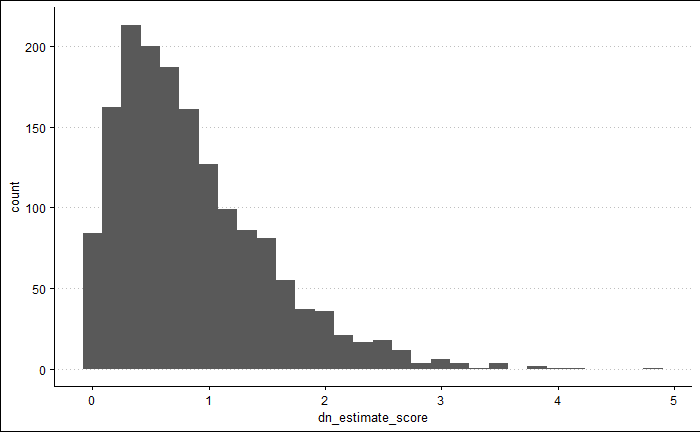

```r
digital_need_mm<-digital_need%>%
  #Select Just the estimates and percentages
  select(ct20_id, noint, noint_p, nocmp, nocmp_p, moblo, moblo_p)%>%
  # Convert Percentages to Decimals and get rid of NAs
  mutate(across(.cols = ends_with("_p"), function(x){ifelse(is.na(x), 0,
                                                            round((x/100),2))}))%>%
  #MinMax Normalization
  mutate(across(.cols = where(is.numeric), function(x, na.rm = TRUE) {
    return(round((x- min(x)) /(max(x)-min(x)),3))}))%>%
  rename_with(~paste(., "mm", sep = "_"))%>%
  rename(ct20_id = ct20_id_mm)

digital_need_full<- full_join(digital_need, digital_need_mm)%>%
  rowwise()%>%
  mutate(dn_estimate_score = sum(noint_mm, nocmp_mm, moblo_mm)*2,
         dn_percent_score = sum(noint_p_mm, nocmp_p_mm, moblo_p_mm)*2)
# Some Visualizations

ggplot(digital_need_full)+
  geom_histogram(aes(dn_estimate_score))+
  theme_clean()
```

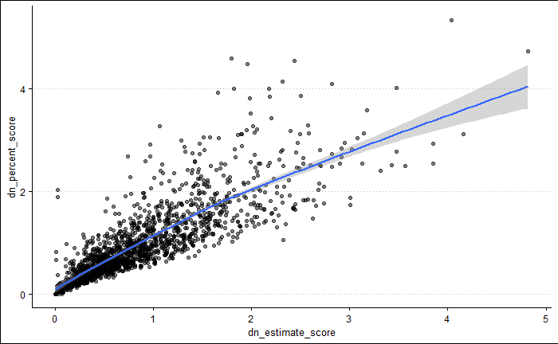

```r
ggplot(digital_need_full)+
  geom_point(aes(x = dn_estimate_score,
                 y = dn_percent_score),
             alpha = 0.5)+
  geom_smooth(aes(x = dn_estimate_score,
                 y = dn_percent_score))+
  theme_clean()
```

# Population Alignment

## Low-income individuals (Comprehensive Affordability Strategy (CHAS) Data Table: Household Income by Tenure;

```
Variable amiu80: Households with Inclusive Low Income (<=80% AMI))

DataCommon Link: https://datacommon.mapc.org/browser/datasets/340


Alternate

b19001_hh_income_acs_ct
```

incu20 incu20_me incu20_p incu20mep inc2039 inc2039_me inc2039_p inc2039mep inc4059 inc4059_me inc4059_p inc4059mep inc6074 inc6074_me inc6074_p inc6074mep

```r
u75<- fetch(dbSendQuery(ch.ds, u75_query), n = -1)%>%
  rowwise()%>%
  mutate(hh_under75k = sum(incu20, inc2039, inc4059, inc6074),
         hh_under75k_p = sum(incu20_p, inc2039_p, inc4059_p, inc6074_p)/100,
         hh_under75kme = moe_sum(moe = c(incu20me, inc2039me, inc4059me, inc6074me),
                             estimate = c(incu20, inc2039, inc4059, inc6074)))%>%
  select(ct20_id, hh_under75k, hh_under75kme, hh_under75k_p)%>%
  ungroup()
```

[output not shown]

## Older adults (ACS Table B01001: Population by Age and Gender;

```
Variable popov65: Population 65 years and over)

popov65m, pop65ovp, and pop65ovp.

DataCommon Link: https://datacommon.mapc.org/browser/datasets/362
```

```r
oa_query <- paste0("SELECT ct20_id, pop65ov, pop65ovm, pop65ovp, pop65ovmp
                        FROM tabular.b01001_population_by_age_gender_acs_ct
                        WHERE acs_year = '", acs_year, "'")

oa <- fetch(dbSendQuery(ch.ds, oa_query), n = -1)%>%
  mutate(pop65ovp = pop65ovp/100)
```

## Veterans (ACS Table S2101: Veteran Status; Variable Veterans)

```
Veterans MOE, % Veterans, % Veterans MOE

Data Link: https://data.census.gov/table?t=Veterans&g=040XX00US25$1400000
```

Tidy Census

```r
acs22<-load_variables(2022, "acs5", cache = FALSE)%>%
  separate(label, into = paste0("label", 1:9), sep = "!!", fill = "right", remove = FALSE)

vets<- get_acs(state = "MA", geography = "tract",
                   variables = c("B21001_001", "B21001_002"),
                   year = 2022)%>%
      left_join(., acs22, by = c("variable" = "name"))%>%
      select(GEOID, label3, estimate, moe)%>%
      mutate(label3 = ifelse(is.na(label3), "Total_Pop", label3))%>%
      pivot_wider(names_from = "label3",
                  values_from = c("estimate", "moe"))%>%
  mutate(vets_p = estimate_Veteran/estimate_Total_Pop,
         vets_pm = moe_ratio(estimate_Veteran, estimate_Total_Pop,
                        moe_Veteran, moe_Total_Pop))%>%
  select(-c(estimate_Total_Pop, moe_Total_Pop))
```

## People living with disability (ACS Tables B18101 through B18107: Civilian Noninstitutionalized Population; Civilian Noninstitutionalized Population 5 Years And Over; Civilian Noninstitutionalized Population 18 Years And Over;

```
Variable disab: Population with disability)

disabm, disabp, and disabpm.

DataCommon Link: https://datacommon.mapc.org/browser/datasets/98
```

```r
dis_query <- paste0("SELECT ct20_id, disab, disabm, disabp, disabmp
                        FROM tabular.b18101_thru_b18107_disability_status_acs_ct
                        WHERE acs_year = '", acs_year, "'")

dis <- fetch(dbSendQuery(ch.ds, dis_query), n = -1)%>%
  rename(disab_p = disabp,
         diabb_pm = disabmp)%>%
  mutate(disab_p = disab_p/100)
```

## People with limited English Language Proficiency - (ACS Table B16004: Language Spoken at Home with Ability to Speak English;

```
Variable en_nw: People speaking another language and do not speak English well)

en_nwme, en_nw_p, and en_nwmep

Data Link: https://datacommon.mapc.org/browser/datasets/78

### Issue: This data is only up to 2021 on datacommon, ACS 2022 does not have this table quickly available in this format

B06007_001
```

```r
elp_query <- paste0("SELECT ct20_id, en_nw, en_nwme, en_nw_p, en_nwmep
                        FROM tabular.b16004_home_language_english_ability_acs_ct
                        WHERE acs_year = '", acs_year, "'")

elp <- fetch(dbSendQuery(ch.ds, elp_query), n = -1)


elp_tc<- get_acs(state = "MA", geography = "tract",
                   variables = c("B06007_001", "B06007_005", "B06007_008"),
                   year = 2022)%>%
      left_join(., acs22, by = c("variable" = "name"))%>%
      select(GEOID, label3, estimate, moe)%>%
      mutate(label3 = ifelse(is.na(label3), "Total_Pop", label3))%>%
      pivot_wider(names_from = "label3",
                  values_from = c("estimate", "moe"))%>%
  rowwise()%>%
  mutate(en_nw = sum(`estimate_Speak Spanish:`, `estimate_Speak other languages:`),
         en_nwme = moe_sum(moe = c(`moe_Speak Spanish:`, `moe_Speak other languages:`),
                           estimate = en_nw),
         en_nw_p = en_nw/estimate_Total_Pop,
         en_nwmep = moe_ratio(en_nw, estimate_Total_Pop,
                        en_nwme, moe_Total_Pop))%>%
  ungroup()%>%
  rename(ct20_id = GEOID)%>%
  select(ct20_id, en_nw, en_nwme, en_nw_p, en_nwmep)
```

## Racial and Ethnic Minority Groups (ACS Table B03002: Race and Ethnicity Estimates;

```
Variable nhwhi: Non-Hispanic White Alone [Used to calculate the population of color.])

nhwhi_me, totpop, totpop_me, nhwhi_p, and nhwhi_mep.

DataCommon Link: https://datacommon.mapc.org/browser/datasets/5
```

```r
poc_query <- paste0("SELECT ct20_id, nhwhi, nhwhi_me, totpop, totpop_me, nhwhi_p, nhwhi_mep
                        FROM tabular.b03002_race_ethnicity_acs_ct
                        WHERE acs_year = '", acs_year, "'")

poc <- fetch(dbSendQuery(ch.ds, poc_query), n = -1)%>%
  mutate(poc = totpop-nhwhi,
         # poc_m = moe_sum(estimate = c(totpop, nhwhi),
         #                 moe = c(totpop_me, nhwhi_me)),
         poc_p = 1 - nhwhi_p/100)%>%
  select(ct20_id, poc, poc_p)
```

## Min Max Population Alignment and Scoring

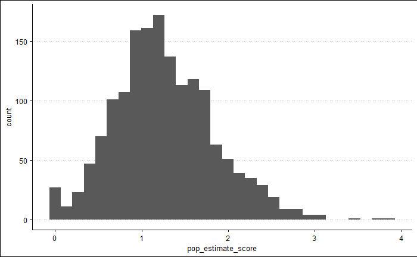

```r
pop_alignment<-left_join(u75, oa, by = "ct20_id")%>%
  #lih%>%
  left_join(vets, by =c("ct20_id"= "GEOID"))%>%
  left_join(dis, by = "ct20_id")%>%
  left_join(elp_tc, by = "ct20_id")%>%
  #left_join(elp, by = "ct20_id")%>%
  left_join(poc, by = "ct20_id")

pop_alignment_mm<-pop_alignment%>%
  #Select Just the estimates and percentages
  select(ct20_id, hh_under75k, hh_under75k_p,
         pop65ov, pop65ovp,
         estimate_Veteran, vets_p,
         disab, disab_p,
         en_nw, en_nw_p,
         poc, poc_p)%>%
  # Convert Percentages to Decimals and get rid of NAs
  mutate(across(.cols = ends_with("p"), function(x){ifelse(is.na(x), 0,
                                                            round(x,2))}))%>%
  #MinMax Normalization
  mutate(across(.cols = where(is.numeric), function(x, na.rm = TRUE) {
    return(round((x- min(x)) /(max(x)-min(x)),3))}))%>%
  rename_with(~paste(., "mm", sep = "_"))%>%
  rename(ct20_id = ct20_id_mm)

# Demographic Scoring

pop_alignment_score<-full_join(pop_alignment, pop_alignment_mm, by = "ct20_id")%>%
  rowwise()%>%
  mutate(pop_estimate_score = sum(hh_under75k_mm, pop65ov_mm, estimate_Veteran_mm, disab_mm, en_nw_mm, poc_mm),
         pop_percent_score = sum(hh_under75k_p_mm, pop65ovp_mm, vets_p_mm, disab_p_mm, en_nw_p_mm, poc_p_mm))

# Some Visualizations

ggplot(pop_alignment_score)+
  geom_histogram(aes(pop_estimate_score))+
  theme_clean()
```

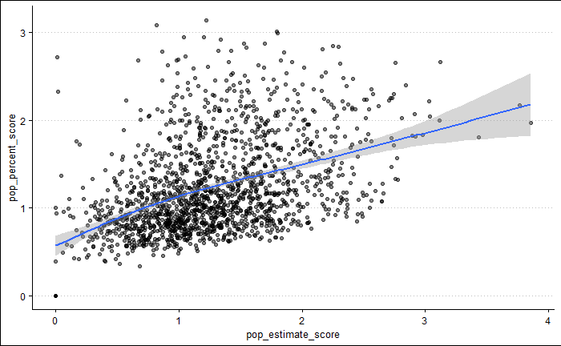

```r
ggplot(pop_alignment_score)+
  geom_point(aes(x = pop_estimate_score,
                 y = pop_percent_score),
             alpha = 0.5)+
  geom_smooth(aes(x = pop_estimate_score,
                 y = pop_percent_score))+
  theme_clean()
```

```r
NA
NA
```

# Compiling Final Table

Going with the estimate score: Because an apartment building will only ever likely be a small share of a census tract, focusing on the estimate of high digital need and vulnerable population will more likely capture the target population

[figure not shown]

```r
qualified_census_tracts<-rio::import("https://docs.huduser.gov/portal/datasets/qct/qct_data_2024.xlsx")%>%
  filter(state == "25")%>%
  select(qct_id, qct)%>%
  mutate(qct_id = str_sub(qct_id, end = 11))
```

```r
buildings<-st_read("K:/DataServices/Datasets/Housing/Multi_Family_Building_Locations/output/State_Subs_Public_Housing_GEOCODE_2024-04-24.shp")%>%
  st_drop_geometry()%>%
  mutate(ct20_id = as.character(ct20_id))
```